# 生统第五次作业 -- 杨天标（第九组）

## Question 1

在一个农业实验中，育种人员测试了3种不同的种子的粮食产量（单位：共计/亩），结果记录在数据yield.txt中。（20’）请问

1. 种子的品种是否影响粮食产量；（10’）
2. 如果受品种影响，那么哪一个品种和其他品种的产量有差异。（10’）

```r
setwd("/Users/tianbiaoyang/Desktop/Learning/knowledge/biometric/data")
```

```r
yield_data <- read.table('第五次作业5.1-yield.txt', head = T)
```

```r
str(yield_data)
```

```
'data.frame':	29 obs. of  2 variables:
 $ yield: int  383 406 351 400 390 361 394 395 414 382 ...
 $ seed : int  1 1 1 1 1 1 1 1 1 1 ...
```

```r
shapiro.test(yield_data$yield[yield_data$seed=="1"])
```

```
	Shapiro-Wilk normality test

data:  yield_data$yield[yield_data$seed == "1"]
W = 0.93955, p-value = 0.548
```

```r
shapiro.test(yield_data$yield[yield_data$seed=="2"])
```

```
	Shapiro-Wilk normality test

data:  yield_data$yield[yield_data$seed == "2"]
W = 0.93528, p-value = 0.4667
```

```r
shapiro.test(yield_data$yield[yield_data$seed=="3"])
```

```
	Shapiro-Wilk normality test

data:  yield_data$yield[yield_data$seed == "3"]
W = 0.97869, p-value = 0.9561
```

```r
bartlett.test(yield~seed, yield_data)
```

```
	Bartlett test of homogeneity of variances

data:  yield by seed
Bartlett's K-squared = 4.0299, df = 2, p-value = 0.1333
```

无显著性差异，可以使用ANOVA检验

```r
yield_data_heng<-c(yield_data$yield[yield_data$seed=="1"],yield_data$yield[yield_data$seed=="2"],yield_data$yield[yield_data$seed=="3"])
yield_data_heng
```

1. 383

2. 406

3. 351

4. 400

5. 390

6. 361

7. 394

8. 395

9. 414

10. 382

11. 362

12. 373

13. 376

14. 371

15. 364

16. 357

17. 372

18. 349

19. 348

20. 360

21. 353

22. 398

23. 380

24. 393

25. 375

26. 365

27. 394

28. 388

29. 407

```r
yield_data_heng<-c(yield_data$yield[yield_data$seed=="1"],yield_data$yield[yield_data$seed=="2"],yield_data$yield[yield_data$seed=="3"])
Dosage<-factor(rep(1:3,c(10,11,8)))
summary(aov(yield_data_heng~Dosage))
```

```
            Df Sum Sq Mean Sq F value   Pr(>F)
Dosage       2   4364  2182.2   10.04 0.000586 ***
Residuals   26   5649   217.3
---
Signif. codes:  0 ‘***’ 0.001 ‘**’ 0.01 ‘*’ 0.05 ‘.’ 0.1 ‘ ’ 1
```

```r
TukeyHSD(aov(yield_data_heng~Dosage))
```

```
  Tukey multiple comparisons of means
    95% family-wise confidence level

Fit: aov(formula = yield_data_heng ~ Dosage)

$Dosage
         diff        lwr       upr     p adj
2-1 -25.32727 -41.330375 -9.324171 0.0015630
3-1  -0.10000 -17.473293 17.273293 0.9998872
3-2  25.22727   8.208575 42.245971 0.0029482
```

## Question 2

为研究茶多酚保健饮料对急性缺氧的影响，某研究者将60只小白鼠随机分为低、中、高三个剂量组和一个对照组，每组15只老鼠。对照组给予蒸馏水0.25ml灌胃，低中高分别给予递增剂量的饮料，并将饮料溶于0.2~0.3ml蒸馏水后灌胃。每天一次，40天后，对小鼠进行耐缺氧存活时间试验，结果见数据文件。（30’）

1) 在本次试验中，为研究不同剂量的茶多酚保健饮料对延长小白鼠的平均耐缺氧存货时间有无差异。问因素或者处理是什么？，与之相对的有多少个分组或者水平？（5’）

因素是茶多酚保健饮料的剂量，有四个分组。

2) 请将数据读入R中，并用Box plot查看总体数据的情况，最后查看一下数据的最小值、中位数、平均数等信息。（5’）

```r
rat_data <- read.table("第五次作业5.2-data.txt", header = T)
```

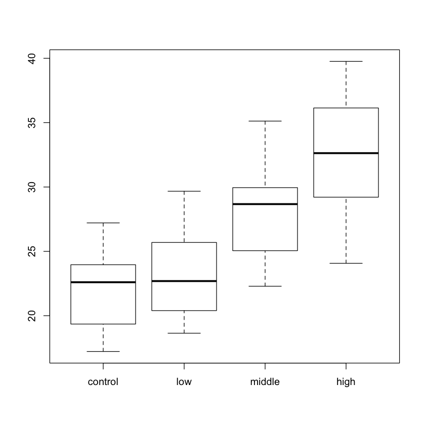

```r
boxplot(rat_data)
```

```r
summary(rat_data)
```

```
    control           low            middle           high
 Min.   :17.22   Min.   :18.64   Min.   :22.29   Min.   :24.07
 1st Qu.:19.35   1st Qu.:20.39   1st Qu.:25.05   1st Qu.:29.21
 Median :22.60   Median :22.69   Median :28.67   Median :32.63
 Mean   :21.98   Mean   :23.23   Mean   :28.13   Mean   :32.84
 3rd Qu.:23.96   3rd Qu.:25.69   3rd Qu.:29.95   3rd Qu.:36.14
 Max.   :27.21   Max.   :29.67   Max.   :35.12   Max.   :39.76
```

3) 有研究员对上述资料采用了两样本均数t检验进行了两两比较。问这样处理是否合理，为什么？应采用何种处理方法。（5’）

不合理，两两比较要比6次，应该使用ANOVA分析。

4) 为了用更好的方法来处理数据，请说明数据应满足的哪三个基本条件？试检验这批数据是否满足这些条件。（提示：一般需要满足三个条件；shapiro.test()函数可检验正态性，bartlett.test()可检验多个正态总体的方差齐次性）（5’）

正态性、方差齐性、多于两组的样本。

```r
shapiro.test(rat_data$control)
shapiro.test(rat_data$low)
shapiro.test(rat_data$middle)
shapiro.test(rat_data$high)
```

```
	Shapiro-Wilk normality test

data:  rat_data$control
W = 0.95001, p-value = 0.5245
```

```
	Shapiro-Wilk normality test

data:  rat_data$low
W = 0.93877, p-value = 0.3671
```

```
	Shapiro-Wilk normality test

data:  rat_data$middle
W = 0.94679, p-value = 0.4754
```

```
	Shapiro-Wilk normality test

data:  rat_data$high
W = 0.95715, p-value = 0.6431
```

数据符合正态分布

```r
bartlett.test(rat_data)
```

```
	Bartlett test of homogeneity of variances

data:  rat_data
Bartlett's K-squared = 2.1206, df = 3, p-value = 0.5478
```

四样本方差齐性

5）请根据上述验证情况，对数据进行分析，并给出差异的配对组别（10’）

```r
str(rat_data)
```

```
'data.frame':	15 obs. of  4 variables:
 $ control: num  20.8 22.9 27.2 19.3 17.9 ...
 $ low    : num  22.2 24.7 21.5 19.7 25.9 ...
 $ middle : num  28.6 28.7 25.3 30.3 23.1 ...
 $ high   : num  31.9 37.9 39.8 27.9 29.6 ...
```

```r
Time<-c(rat_data$control,rat_data$low,rat_data$middle,rat_data$high)
Dosage<-factor(rep(1:4,c(15,15,15,15)))
```

```r
summary(aov(Time~Dosage))
```

```
            Df Sum Sq Mean Sq F value   Pr(>F)
Dosage       3 1109.1   369.7   24.46 3.03e-10 ***
Residuals   56  846.5    15.1
---
Signif. codes:  0 ‘***’ 0.001 ‘**’ 0.01 ‘*’ 0.05 ‘.’ 0.1 ‘ ’ 1
```

```r
TukeyHSD(aov(Time~Dosage))
```

```
  Tukey multiple comparisons of means
    95% family-wise confidence level

Fit: aov(formula = Time ~ Dosage)

$Dosage
         diff        lwr       upr     p adj
2-1  1.254667 -2.5044218  5.013755 0.8132480
3-1  6.151333  2.3922449  9.910422 0.0003513
4-1 10.860000  7.1009116 14.619088 0.0000000
3-2  4.896667  1.1375782  8.655755 0.0057640
4-2  9.605333  5.8462449 13.364422 0.0000001
4-3  4.708667  0.9495782  8.467755 0.0084746
```

三、已知有三种药物都能促进小鼠肠道对营养的吸收，现将初始状态相近的两批成年小鼠分别进行给药，经过一段时间后测量其体重，然后得到这段时间内小鼠体重增加的值。问：这三种药导致的平均体重增加值有无统计学差异？（20’）

[figure not shown]

```r
Drug_1 <- c(40,10,35,25,20,15,35,15,-5,30,25,70,65,45,50)
Drug_2 <- c(50,20,45,55,20,15,80,-10,105,75,10,60,45,60,30)
Drug_3 <- c(60,30,100,85,20,55,45,30,77,105)
```

```r
GainWeight<-c(Drug_1,Drug_2,Drug_3)
```

```r
Drug<-factor(rep(1:3,c(15,15,10)))
Drug
```

1. 1

2. 1

3. 1

4. 1

5. 1

6. 1

7. 1

8. 1

9. 1

10. 1

11. 1

12. 1

13. 1

14. 1

15. 1

16. 2

17. 2

18. 2

19. 2

20. 2

21. 2

22. 2

23. 2

24. 2

25. 2

26. 2

27. 2

28. 2

29. 2

30. 2

31. 3

32. 3

33. 3

34. 3

35. 3

36. 3

37. 3

38. 3

39. 3

40. 3

**Levels**:**

1. '1'

2. '2'

3. '3'

进行正态分析

```r
shapiro.test(Drug_1)
```

```
	Shapiro-Wilk normality test

data:  Drug_1
W = 0.9778, p-value = 0.9523
```

```r
shapiro.test(Drug_2)
```

```
	Shapiro-Wilk normality test

data:  Drug_2
W = 0.98349, p-value = 0.9878
```

```r
shapiro.test(Drug_3)
```

```
	Shapiro-Wilk normality test

data:  Drug_3
W = 0.94005, p-value = 0.5536
```

各样本均有正态性

```r
bartlett.test(GainWeight~Drug)
```

```
	Bartlett test of homogeneity of variances

data:  GainWeight by Drug
Bartlett's K-squared = 2.4482, df = 2, p-value = 0.294
```

方差齐

```r
summary(aov(GainWeight~Drug))
```

```
            Df Sum Sq Mean Sq F value Pr(>F)
Drug         2   5062  2531.2   3.485 0.0411 *
Residuals   37  26877   726.4
---
Signif. codes:  0 ‘***’ 0.001 ‘**’ 0.01 ‘*’ 0.05 ‘.’ 0.1 ‘ ’ 1
```

```r
TukeyHSD(aov(GainWeight~Drug))
```

```
  Tukey multiple comparisons of means
    95% family-wise confidence level

Fit: aov(formula = GainWeight ~ Drug)

$Drug
        diff        lwr      upr     p adj
2-1 12.33333 -11.694604 36.36127 0.4302024
3-1 29.03333   2.169283 55.89738 0.0317315
3-2 16.70000 -10.164050 43.56405 0.2944100
```

结论:药物 3 与药物 1 相比，有显著差异。

## Question 4

四、在一生物实验中，为了研究不同饲养条件对大鼠体重的影响，现将60只8周龄体重相等的大鼠随机分为六组，分别放入以下饲养条件中培养两周： A：饲养温度（。C） 4（A1），25（A2），30（A3） B：饲料：普通饲料（B1），高脂饲料（B2） 最后测得体重为下表

[figure not shown]

### 第一问

```r
BodyWeight=c(282.1,264.2,274.2,276.4,283.7,288,274.3,278.4,293.5,271.5,296.7,318,295.3,292.8,304.5,305.9,312.3,311.4,307.6,292.7,300.1, 307.5,294.2,312,300.2,292.6,302,306.9,313.3,312.4,284.5,263.7,292.3, 270.3,281.3,286.9,271.2,275.6,289.4,289.8,296.6,323.9,296.5,298.1,310,312.5,317.6,305.5,305.8,295.4,304,312.4,297.8,318.4,302.4,295.3,305.5,309.9,319.2,320.2)
```

```r
Data<-data.frame(BodyWeight=BodyWeight, Fodder=gl(2,30,60,labels=c("B1","B2")),Temperature=gl(3,10,60,labels=c("A1","A2","A3")))
```

```r
shapiro.test(Data$BodyWeight[Data$Temperature=="A1"])
```

```
	Shapiro-Wilk normality test

data:  Data$BodyWeight[Data$Temperature == "A1"]
W = 0.96118, p-value = 0.5676
```

```r
shapiro.test(Data$BodyWeight[Data$Temperature=="A2"])
```

```
	Shapiro-Wilk normality test

data:  Data$BodyWeight[Data$Temperature == "A2"]
W = 0.93573, p-value = 0.1989
```

```r
shapiro.test(Data$BodyWeight[Data$Temperature=="A3"])
```

```
	Shapiro-Wilk normality test

data:  Data$BodyWeight[Data$Temperature == "A3"]
W = 0.96408, p-value = 0.6281
```

```r
shapiro.test(Data$BodyWeight[Data$Fodder=="B1"])
```

```
	Shapiro-Wilk normality test

data:  Data$BodyWeight[Data$Fodder == "B1"]
W = 0.95026, p-value = 0.1718
```

```r
shapiro.test(Data$BodyWeight[Data$Fodder=="B2"])
```

```
	Shapiro-Wilk normality test

data:  Data$BodyWeight[Data$Fodder == "B2"]
W = 0.96797, p-value = 0.4853
```

```r
bartlett.test(Data$BodyWeight~Data$Temperature)
```

```
	Bartlett test of homogeneity of variances

data:  Data$BodyWeight by Data$Temperature
Bartlett's K-squared = 0.19888, df = 2, p-value = 0.9053
```

```r
var.test(Data$BodyWeight[1:30],Data$BodyWeight[31:60])
```

```
	F test to compare two variances

data:  Data$BodyWeight[1:30] and Data$BodyWeight[31:60]
F = 0.84234, num df = 29, denom df = 29, p-value = 0.6472
alternative hypothesis: true ratio of variances is not equal to 1
95 percent confidence interval:
 0.4009265 1.7697632
sample estimates:
ratio of variances
         0.8423449
```

综上，各样本均服从正态分布，方差齐性

### 第二问

```r
summary(aov(Data$BodyWeight~Data$Fodder*Data$Temperature))
```

```
                             Df Sum Sq Mean Sq F value   Pr(>F)
Data$Fodder                   1    127     127   1.589    0.213
Data$Temperature              2   9080    4540  56.809 5.22e-14 ***
Data$Fodder:Data$Temperature  2     17       9   0.108    0.897
Residuals                    54   4316      80
---
Signif. codes:  0 ‘***’ 0.001 ‘**’ 0.01 ‘*’ 0.05 ‘.’ 0.1 ‘ ’ 1
```

经 Two-way ANOVA 分析后，Fodder 因素，即 B 因素对应 p-value 为 0.213，大于 0.05，故没有显著性;Temperature 因素，即 A 因素对应 p-value 为 5.22e-14，远小于 0.05， 十分显著性;A 与 B 交互因素，对应 p-value 为 0.897，大于 0.05，故没有显著性。所以， 只有 A 因素即温度对大鼠体重有显著性影响。

### 第三问

```r
TukeyHSD(aov(Data$BodyWeight~Data$Fodder*Data$Temperature))
```

```
  Tukey multiple comparisons of means
    95% family-wise confidence level

Fit: aov(formula = Data$BodyWeight ~ Data$Fodder * Data$Temperature)

$`Data$Fodder`
      diff       lwr      upr     p adj
B2-B1 2.91 -1.717782 7.537782 0.2128406

$`Data$Temperature`
       diff       lwr       upr     p adj
A2-A1 25.39 18.576905 32.203095 0.0000000
A3-A1 26.75 19.936905 33.563095 0.0000000
A3-A2  1.36 -5.453095  8.173095 0.8805321

$`Data$Fodder:Data$Temperature`
             diff        lwr       upr     p adj
B2:A1-B1:A1  1.87  -9.942078 13.682078 0.9970585
B1:A2-B1:A1 25.09  13.277922 36.902078 0.0000009
B2:A2-B1:A1 27.56  15.747922 39.372078 0.0000001
B1:A3-B1:A1 25.49  13.677922 37.302078 0.0000006
B2:A3-B1:A1 29.88  18.067922 41.692078 0.0000000
B1:A2-B2:A1 23.22  11.407922 35.032078 0.0000050
B2:A2-B2:A1 25.69  13.877922 37.502078 0.0000005
B1:A3-B2:A1 23.62  11.807922 35.432078 0.0000035
B2:A3-B2:A1 28.01  16.197922 39.822078 0.0000001
B2:A2-B1:A2  2.47  -9.342078 14.282078 0.9892562
B1:A3-B1:A2  0.40 -11.412078 12.212078 0.9999985
B2:A3-B1:A2  4.79  -7.022078 16.602078 0.8358408
B1:A3-B2:A2 -2.07 -13.882078  9.742078 0.9952518
B2:A3-B2:A2  2.32  -9.492078 14.132078 0.9919360
B2:A3-B1:A3  4.39  -7.422078 16.202078 0.8800277
```

多重比较结果如上，在与 A2B1 组相比时，只有 A1B1、A1B2 两组 p-value 小于 0.05， 具有显著性差异，另外三组没有。